# Introduction to R

[Saeed Saffari](https://www.saeedsaffari.com)[^1]

Saeedeh Malekan[^2]

Fall 2021

# 1 Introduction

You can download and install packages with `install.packages("The name of package")`.

# 2 Basic of learning

In this part we talk about basic elements of R programming.

$\bullet$ Note that this is only a brief overview of **R programming**, and before that you should be familiar with the **Python programming language**.

## 2.1 How to Print

```r
print("This is R programming Course")
```

```
[1] "This is R programming Course"
```

## 2.2 Arithmetic Operators

| Symbol | Task Performed |
| --- | --- |
| + | Addition |
| - | Subtraction |
| / | division |
| * | multiplication |
| ** | to the power of |
| ^ | to the power of |
| %% | modulus |
| %/% | floor division |

```r
18 + 4
```

```
[1] 22
```

```r
18 - 4
```

```
[1] 14
```

```r
18 * 4
```

```
[1] 72
```

```r
10 / 2
```

```
[1] 5
```

```r
2 ** 3
```

```
[1] 8
```

```r
2 ^ 3
```

```
[1] 8
```

```r
9 ** 0.5
```

```
[1] 3
```

```r
log10(2)
```

```
[1] 0.30103
```

```r
5 + ( 4 - 3 * 2)**3 + 1
```

```
[1] -2
```

```r
14 %% 4
```

```
[1] 2
```

```r
8 %/% 3
```

```
[1] 2
```

**we can save values in variables:**

```r
x <- 18
y <- 4
z <- x + y
print(z)
```

```
[1] 22
```

```r
z
```

```
[1] 22
```

```r
class(z)
```

```
[1] "numeric"
```

```r
a = 'R Programming'
class(a)
```

```
[1] "character"
```

## 2.3 Relational Operators

| Symbol | Task Performed |
| --- | --- |
| <- | Assignment |
| = | Assignment |
| assign() | Assignment |
| == | True, if it is equal |
| != | True, if not equal to |
| < | less than |
| > | greater than |
| <= | less than or equal to |
| >= | greater than or equal to |

```r
z <- 10
y = 18
assign('x', 30)
z
```

```
[1] 10
```

```r
y
```

```
[1] 18
```

```r
x
```

```
[1] 30
```

```r
x < y
```

```
[1] FALSE
```

```r
x >= y
```

```
[1] TRUE
```

```r
x != y
```

```
[1] TRUE
```

```r
x == y
```

```
[1] FALSE
```

**you can use below command to get special values:**

```r
x <- pi
x
```

```
[1] 3.141593
```

```r
x <- letters
x
```

```
 [1] "a" "b" "c" "d" "e" "f" "g" "h" "i" "j" "k" "l" "m" "n" "o" "p" "q" "r" "s" "t" "u" "v" "w"
[24] "x" "y" "z"
```

```r
x <- LETTERS
x
```

```
 [1] "A" "B" "C" "D" "E" "F" "G" "H" "I" "J" "K" "L" "M" "N" "O" "P" "Q" "R" "S" "T" "U" "V" "W"
[24] "X" "Y" "Z"
```

```r
x <- month.name
x
```

```
 [1] "January"   "February"  "March"     "April"     "May"       "June"      "July"
 [8] "August"    "September" "October"   "November"  "December"
```

```r
x <- month.abb
x
```

```
 [1] "Jan" "Feb" "Mar" "Apr" "May" "Jun" "Jul" "Aug" "Sep" "Oct" "Nov" "Dec"
```

**you can write comment with # :**

```r
# This line is comment.
```

**you can creat sequence numbers with below command:**

This work like *arange* in numpy pakage in Python

```r
x <- 1:10
x
```

```
 [1]  1  2  3  4  5  6  7  8  9 10
```

```r
x <- 1:10 * 2
x
```

```
 [1]  2  4  6  8 10 12 14 16 18 20
```

```r
x <- seq(5)
x
```

```
[1] 1 2 3 4 5
```

```r
x <- seq(from = 1, to = 9)
x
```

```
[1] 1 2 3 4 5 6 7 8 9
```

```r
x <- seq(from = 1, to = 9, by = 3)
x
```

```
[1] 1 4 7
```

```r
x <- seq(1, 10, 2)
x
```

```
[1] 1 3 5 7 9
```

This work like *linsapce* in numpy pakage in Python

```r
x <- seq(1, 10, length = 4)
x
```

```
[1]  1  4  7 10
```

Replicate function:

```r
x <- 1:3
x
```

```
[1] 1 2 3
```

```r
y <- rep(x, times = 5)
y
```

```
 [1] 1 2 3 1 2 3 1 2 3 1 2 3 1 2 3
```

```r
y <- rep(x, each = 5)
y
```

```
 [1] 1 1 1 1 1 2 2 2 2 2 3 3 3 3 3
```

## 2.4 Loops

### 2.4.1 if , elif

```r
age <- 18#as.integer(readline(prompt('Enter your age: ')))

if (age >= 18){
  print("You are old enough to vote!")
} else {
  print('You can NOT vote yet!')
  print(paste("you can will vote after ", 18 - age, " years."))
}
```

```
[1] "You are old enough to vote!"
```

```r
age <- 10 # as.integer(readline(prompt('Enter your age: ')))

if (age <= 4){
  price = 0
} else if (age <= 16){
  price = 5
} else {
  price = 10
}

print(paste("your cost is $",price,"."))
```

```
[1] "your cost is $ 5 ."
```

### 2.4.2 for loops

```r
for (i in 1:5){
  print(i)
}
```

```
[1] 1
[1] 2
[1] 3
[1] 4
[1] 5
```

### 2.4.3 while loops

```r
i <- 1
while (i < 10){
  print(i)
  i <- i + 1
}
```

```
[1] 1
[1] 2
[1] 3
[1] 4
[1] 5
[1] 6
[1] 7
[1] 8
[1] 9
```

**Use break and next in loops**

```r
for (i in 1:10){
  if (i == 5){
    break
  }
  print(i)
}
```

```
[1] 1
[1] 2
[1] 3
[1] 4
```

```r
for (i in 1:10){
  if (i == 5){
    next
  }
  print(i)
}
```

```
[1] 1
[1] 2
[1] 3
[1] 4
[1] 6
[1] 7
[1] 8
[1] 9
[1] 10
```

## 2.5 function

```r
ave = function(a, b, c){
  summ = a + b + c
  ave = summ / 3
  return( ave)
}

ave(34, 13, -21)
```

```
[1] 8.666667
```

```r
ave = function(a, b , c){
  #a <- as.integer(readline(prompt('Enter your first number: ')))
  #b <- as.integer(readline(prompt('Enter your second number: ')))
  #c <- as.integer(readline(prompt('Enter your third number: ')))
  summ = a + b + c
  ave = summ / 3
  return( ave)
}

ave(12, 13, 14)
```

```
[1] 13
```

# 3 Vetors

The most common way to creat vectors is to use function `c()`.

```r
x <- c(10.25, 3.5, 8.75, 23.15)
x
```

```
[1] 10.25  3.50  8.75 23.15
```

```r
x <- c('a', "b", 'C')
x
```

```
[1] "a" "b" "C"
```

```r
# all elemets have same type
x <- c(10.25, 3.5, 8.75, 23.15, 'a', "b", 'C')
x
```

```
[1] "10.25" "3.5"   "8.75"  "23.15" "a"     "b"     "C"
```

```r
x <- c(1,2,4,5,6,7)
x
```

```
[1] 1 2 4 5 6 7
```

```r
y <- 1:7
y
```

```
[1] 1 2 3 4 5 6 7
```

**Concat vectors**

```r
x <- c(10,20,30,40)

y <- c(3.5, 4.75)

z <- c(x, y)
z
```

```
[1] 10.00 20.00 30.00 40.00  3.50  4.75
```

You can find *lenght* of vectors with *lenght()* function:

```r
x <- c(1.5,3.25,8.75,13.15)
x
```

```
[1]  1.50  3.25  8.75 13.15
```

```r
length(x)
```

```
[1] 4
```

## 3.1 Vector Indexing

```r
x <- c(10,45,30,50,35,40,80)
x
```

```
[1] 10 45 30 50 35 40 80
```

```r
x[1]
```

```
[1] 10
```

```r
x[-2]
```

```
[1] 10 30 50 35 40 80
```

```r
x[3:7]
```

```
[1] 30 50 35 40 80
```

```r
x[c(1,3,4)]
```

```
[1] 10 30 50
```

```r
length(x)
```

```
[1] 7
```

```r
x[10]
```

```
[1] NA
```

```r
x[2] <- -8
x
```

```
[1] 10 -8 30 50 35 40 80
```

```r
x[10] <- 9
x
```

```
 [1] 10 -8 30 50 35 40 80 NA NA  9
```

```r
x[-3] <- 6
x
```

```
 [1]  6  6 30  6  6  6  6  6  6  6
```

```r
x <- c(10,45,30,50,35,40,80)
y <- c(TRUE,FALSE,TRUE,FALSE,FALSE,FALSE,TRUE)
x[y]
```

```
[1] 10 30 80
```

Use for loops for access to elemets of vectors

```r
for (i in x){
 print(i)
}
```

```
[1] 10
[1] 45
[1] 30
[1] 50
[1] 35
[1] 40
[1] 80
```

Use index:

```r
for (i in 1:length(x)){
 print(x[i])
}
```

```
[1] 10
[1] 45
[1] 30
[1] 50
[1] 35
[1] 40
[1] 80
```

```r
for (i in 1:10){
 print(x[i])
}
```

```
[1] 10
[1] 45
[1] 30
[1] 50
[1] 35
[1] 40
[1] 80
[1] NA
[1] NA
[1] NA
```

## 3.2 Matching Operator

```r
x <- c(10,45,30,50,35,40,80)


35 %in% x
```

```
[1] TRUE
```

```r
37 %in% x
```

```
[1] FALSE
```

```r
y <- c(30, 37, 45)

y %in% x
```

```
[1]  TRUE FALSE  TRUE
```

## 3.3 Vector Arthmetic’s

```r
x <- c(10,45,30,50)
x
```

```
[1] 10 45 30 50
```

```r
x + 2
```

```
[1] 12 47 32 52
```

```r
x <- x * 2
x
```

```
[1]  20  90  60 100
```

```r
sqrt(x)
```

```
[1]  4.472136  9.486833  7.745967 10.000000
```

```r
x <- c(10,45,30,50)
y <- c(5,1,2,4)

x + y
```

```
[1] 15 46 32 54
```

```r
z <- c(10,20,30)
x + z
```

```
[1] 20 65 60 60
```

## 3.4 Vector Methods

```r
x <- c(10,45,30,50)
length(x)
```

```
[1] 4
```

```r
sum(x)
```

```
[1] 135
```

```r
prod(x)
```

```
[1] 675000
```

```r
rev(x)
```

```
[1] 50 30 45 10
```

```r
sort(x)
```

```
[1] 10 30 45 50
```

```r
sort(x, decreasing =  TRUE)
```

```
[1] 50 45 30 10
```

```r
x <- c(10,45,30,50)
y <- c(5,1,4,3)

x %*% y
```

```
     [,1]
[1,]  365
```

```r
crossprod(x,y)
```

```
     [,1]
[1,]  365
```

```r
x %o% y
```

```
     [,1] [,2] [,3] [,4]
[1,]   50   10   40   30
[2,]  225   45  180  135
[3,]  150   30  120   90
[4,]  250   50  200  150
```

```r
tcrossprod(x,y)
```

```
     [,1] [,2] [,3] [,4]
[1,]   50   10   40   30
[2,]  225   45  180  135
[3,]  150   30  120   90
[4,]  250   50  200  150
```

## 3.5 Logical Vector

```r
x <- c(10,45,30,50,35)
x
```

```
[1] 10 45 30 50 35
```

```r
y <- x > 30 & x < 50
y
```

```
[1] FALSE  TRUE FALSE FALSE  TRUE
```

```r
x[y]
```

```
[1] 45 35
```

```r
x <- c(10,45,30,50,35)
y <- c(20,15,25,65,5)

x < y
```

```
[1]  TRUE FALSE FALSE  TRUE FALSE
```

```r
x[x <y]
```

```
[1] 10 50
```

```r
x <- c(10,45,30,50,35)
which(x>30)
```

```
[1] 2 4 5
```

```r
x[which(x>30)]
```

```
[1] 45 50 35
```

## 3.6 Factors

- Used to represent categorical data
- Treated as integer vector, having a label
- Factors are self describing

```r
x <- c('Male', "Female", "Male", 'Male', "Female")
x
```

```
[1] "Male"   "Female" "Male"   "Male"   "Female"
```

```r
x <- factor(c('Male', "Female", "Male", 'Male', "Female"))
x
```

```
[1] Male   Female Male   Male   Female
Levels: Female Male
```

```r
table(x)
```

```
x
Female   Male
     2      3
```

## 3.7 Mathematical Function in R

```r
x <- c(4.258, -3.853, 5.457, 7.504)
abs(x)
```

```
[1] 4.258 3.853 5.457 7.504
```

```r
ceiling(x)  #next integer
```

```
[1]  5 -3  6  8
```

```r
floor(x)   #samller integer
```

```
[1]  4 -4  5  7
```

```r
round(x)
```

```
[1]  4 -4  5  8
```

```r
round(x, digits = 2)
```

```
[1]  4.26 -3.85  5.46  7.50
```

```r
x <- c(16,36,30,81,25)
sqrt(x)
```

```
[1] 4.000000 6.000000 5.477226 9.000000 5.000000
```

```r
log(x)
```

```
[1] 2.772589 3.583519 3.401197 4.394449 3.218876
```

```r
log(x, base = 2)
```

```
[1] 4.000000 5.169925 4.906891 6.339850 4.643856
```

```r
log(x, base = 10)
```

```
[1] 1.204120 1.556303 1.477121 1.908485 1.397940
```

```r
log10(x)
```

```
[1] 1.204120 1.556303 1.477121 1.908485 1.397940
```

```r
x <- c(4,3,6)
factorial(x)
```

```
[1]  24   6 720
```

## 3.8 Random Number in R

```r
x <- rnorm(10)  # mean = 0 and std = 1
x
```

```
 [1] -1.7768480  0.4403862  0.2089144  1.8503114  0.4854725 -1.2505543  1.1585764  1.0424758
 [9]  0.2428394 -1.6903695
```

```r
x <- rnorm(10, mean = 0, sd = 1)

mean(x)
```

```
[1] -0.5987489
```

```r
sd(x)
```

```
[1] 0.9119683
```

# 4 Matrix

## 4.1 Creat Matrix

Matrix are 2-dimentsional vectors and Dimensianal attribute is of lenght 2 (rows and columns). We should to know that Matrix contain elemts of same type.

```r
m <- matrix(nrow = 2, ncol = 3)
m
```

```
     [,1] [,2] [,3]
[1,]   NA   NA   NA
[2,]   NA   NA   NA
```

```r
dim(m)    # dimension
```

```
[1] 2 3
```

```r
dim(m)[1]
```

```
[1] 2
```

```r
m <- matrix(c(1,2,3,4,5,6))
m
```

```
     [,1]
[1,]    1
[2,]    2
[3,]    3
[4,]    4
[5,]    5
[6,]    6
```

```r
m <- matrix(c(1,2,3,4,5,6), nrow = 2,ncol = 3)
m
```

```
     [,1] [,2] [,3]
[1,]    1    3    5
[2,]    2    4    6
```

```r
m <- matrix(c(1,2,3,4,5,6), nrow = 2,ncol = 3, byrow = TRUE)
m
```

```
     [,1] [,2] [,3]
[1,]    1    2    3
[2,]    4    5    6
```

```r
m <- matrix(seq(from = 1, to = 40, by = 2), nrow = 4, ncol = 5, byrow = TRUE)
m
```

```
     [,1] [,2] [,3] [,4] [,5]
[1,]    1    3    5    7    9
[2,]   11   13   15   17   19
[3,]   21   23   25   27   29
[4,]   31   33   35   37   39
```

```r
dim(m)
```

```
[1] 4 5
```

```r
nrow(m)
```

```
[1] 4
```

```r
ncol(m)
```

```
[1] 5
```

```r
length(m)
```

```
[1] 20
```

## 4.2 Matrix diag

like `numpy.full` in python

```r
m <- matrix(4,3,3)
m
```

```
     [,1] [,2] [,3]
[1,]    4    4    4
[2,]    4    4    4
[3,]    4    4    4
```

like `numpy.diag` in python

```r
m <- diag(1,3,3)
m
```

```
     [,1] [,2] [,3]
[1,]    1    0    0
[2,]    0    1    0
[3,]    0    0    1
```

```r
m <- diag(4)
m
```

```
     [,1] [,2] [,3] [,4]
[1,]    1    0    0    0
[2,]    0    1    0    0
[3,]    0    0    1    0
[4,]    0    0    0    1
```

```r
m <- diag(1:5)
m
```

```
     [,1] [,2] [,3] [,4] [,5]
[1,]    1    0    0    0    0
[2,]    0    2    0    0    0
[3,]    0    0    3    0    0
[4,]    0    0    0    4    0
[5,]    0    0    0    0    5
```

for find the elements of diagonal of matrix:

```r
m <- matrix(seq(from = 1, to = 40, by = 2), nrow = 4, ncol = 5, byrow = TRUE)
m
```

```
     [,1] [,2] [,3] [,4] [,5]
[1,]    1    3    5    7    9
[2,]   11   13   15   17   19
[3,]   21   23   25   27   29
[4,]   31   33   35   37   39
```

```r
diag(m)
```

```
[1]  1 13 25 37
```

## 4.3 Matrix: Naming Rows & Columns

```r
m <- matrix(c(2,3,4,0,1,2,-1,-3,5), nrow = 3, ncol = 3, byrow = TRUE)
m
```

```
     [,1] [,2] [,3]
[1,]    2    3    4
[2,]    0    1    2
[3,]   -1   -3    5
```

```r
rownames(m) <- c(1,2,3)
colnames(m) <- c("A", "B", 'C')
m
```

```
   A  B C
1  2  3 4
2  0  1 2
3 -1 -3 5
```

## 4.4 Matrix Indexing

Indexing in R programming is similar to Python.

```r
m <- matrix(c(2,3,4,0,1,2,-1,-2,5,8,6,-3), nrow = 4, ncol = 3, byrow = TRUE)
m
```

```
     [,1] [,2] [,3]
[1,]    2    3    4
[2,]    0    1    2
[3,]   -1   -2    5
[4,]    8    6   -3
```

```r
m[1,2]
```

```
[1] 3
```

```r
m[1,]  # for get single row
```

```
[1] 2 3 4
```

```r
m[,2]  # for get single column
```

```
[1]  3  1 -2  6
```

```r
m[,1:2]
```

```
     [,1] [,2]
[1,]    2    3
[2,]    0    1
[3,]   -1   -2
[4,]    8    6
```

```r
m[1:3,1:2]
```

```
     [,1] [,2]
[1,]    2    3
[2,]    0    1
[3,]   -1   -2
```

```r
m[,c(1,3)]
```

```
     [,1] [,2]
[1,]    2    4
[2,]    0    2
[3,]   -1    5
[4,]    8   -3
```

```r
m[, -2]  # every columns except 2
```

```
     [,1] [,2]
[1,]    2    4
[2,]    0    2
[3,]   -1    5
[4,]    8   -3
```

You can change values in matrix as like as Python.

```r
m <- matrix(c(2,3,4,0,1,2,-1,-2,5,8,6,-3), nrow = 4, ncol = 3, byrow = TRUE)
m
```

```
     [,1] [,2] [,3]
[1,]    2    3    4
[2,]    0    1    2
[3,]   -1   -2    5
[4,]    8    6   -3
```

```r
m[2,3] = 9
m
```

```
     [,1] [,2] [,3]
[1,]    2    3    4
[2,]    0    1    9
[3,]   -1   -2    5
[4,]    8    6   -3
```

## 4.5 Matrix: `rbine()` and `cbind()` functions

You can combine matrices with `rbine()` and `cbind()` functions.

At first, we want to combine the matrices from the row.

```r
A <- matrix(c(2,3,4,0,1,2,-1,-2,5), nrow = 3, ncol = 3, byrow = TRUE)
A
```

```
     [,1] [,2] [,3]
[1,]    2    3    4
[2,]    0    1    2
[3,]   -1   -2    5
```

```r
B <- rbind(A, c(10,11,12))
B
```

```
     [,1] [,2] [,3]
[1,]    2    3    4
[2,]    0    1    2
[3,]   -1   -2    5
[4,]   10   11   12
```

```r
B <- matrix(1:6, nrow = 2, ncol = 3, byrow = TRUE)
B
```

```
     [,1] [,2] [,3]
[1,]    1    2    3
[2,]    4    5    6
```

```r
C <- rbind(A,B)
C
```

```
     [,1] [,2] [,3]
[1,]    2    3    4
[2,]    0    1    2
[3,]   -1   -2    5
[4,]    1    2    3
[5,]    4    5    6
```

After that, we want to combine the matrices from the columns.

```r
A <- matrix(c(2,3,4,0,1,2,-1,-2,5), nrow = 3, ncol = 3, byrow = TRUE)
A
```

```
     [,1] [,2] [,3]
[1,]    2    3    4
[2,]    0    1    2
[3,]   -1   -2    5
```

```r
B <- cbind(A, c(10,11,12))
B
```

```
     [,1] [,2] [,3] [,4]
[1,]    2    3    4   10
[2,]    0    1    2   11
[3,]   -1   -2    5   12
```

```r
B <- matrix(1:6, nrow = 3, ncol = 2)
B
```

```
     [,1] [,2]
[1,]    1    4
[2,]    2    5
[3,]    3    6
```

```r
C <- cbind(A,B)
C
```

```
     [,1] [,2] [,3] [,4] [,5]
[1,]    2    3    4    1    4
[2,]    0    1    2    2    5
[3,]   -1   -2    5    3    6
```

Relational Operators in Matrics:

```r
A <- matrix(c(1,2,3,4,5,6,8,9,1) , nrow=3, ncol=3, byrow=TRUE)
B <- matrix(c(3,1,2,4,2,1,5,1,2), nrow=3, ncol=3, byrow=TRUE)

A
```

```
     [,1] [,2] [,3]
[1,]    1    2    3
[2,]    4    5    6
[3,]    8    9    1
```

```r
B
```

```
     [,1] [,2] [,3]
[1,]    3    1    2
[2,]    4    2    1
[3,]    5    1    2
```

```r
A + B
```

```
     [,1] [,2] [,3]
[1,]    4    3    5
[2,]    8    7    7
[3,]   13   10    3
```

```r
A - B
```

```
     [,1] [,2] [,3]
[1,]   -2    1    1
[2,]    0    3    5
[3,]    3    8   -1
```

```r
A * B
```

```
     [,1] [,2] [,3]
[1,]    3    2    6
[2,]   16   10    6
[3,]   40    9    2
```

```r
A / B
```

```
          [,1] [,2] [,3]
[1,] 0.3333333  2.0  1.5
[2,] 1.0000000  2.5  6.0
[3,] 1.6000000  9.0  0.5
```

Like `numpy.transpose()` or `.T` in python

```r
A <- matrix(c(1,2,3,4,5,6,8,9,1,4,2,3) , nrow=3, ncol=4, byrow=TRUE)
A
```

```
     [,1] [,2] [,3] [,4]
[1,]    1    2    3    4
[2,]    5    6    8    9
[3,]    1    4    2    3
```

```r
t(A)
```

```
     [,1] [,2] [,3]
[1,]    1    5    1
[2,]    2    6    4
[3,]    3    8    2
[4,]    4    9    3
```

## 4.6 Matrix Specific Functions

```r
A <- matrix(1:9,3,3)
A
```

```
     [,1] [,2] [,3]
[1,]    1    4    7
[2,]    2    5    8
[3,]    3    6    9
```

```r
rowSums(A)
```

```
[1] 12 15 18
```

```r
colSums(A)
```

```
[1]  6 15 24
```

```r
rowMeans(A)
```

```
[1] 4 5 6
```

```r
colMeans(A)
```

```
[1] 2 5 8
```

# 5 Lists

## 5.1 Creat list

`Lists` are also collecting of data and another kind of data storage. Lists can contain elemnts of any type of R object and these elements of list don’t need be same type. You can creat list by using `list()` function.

```r
x <- list(10, 'Saeed', TRUE)
x
```

```
[[1]]
[1] 10

[[2]]
[1] "Saeed"

[[3]]
[1] TRUE
```

Creat list with vectors

```r
classno <- c(101,102,103)
name <- c("Mahshid", "Saeed", "Sara")
scores <- c(98.45, 45.65, 78.79)
students <- list(classno, name, scores)
students
```

```
[[1]]
[1] 101 102 103

[[2]]
[1] "Mahshid" "Saeed"   "Sara"

[[3]]
[1] 98.45 45.65 78.79
```

```r
students[1]
```

```
[[1]]
[1] 101 102 103
```

```r
students[[1]]
```

```
[1] 101 102 103
```

```r
students[[1]][2]
```

```
[1] 102
```

```r
students[[1]][2] = 109
students
```

```
[[1]]
[1] 101 109 103

[[2]]
[1] "Mahshid" "Saeed"   "Sara"

[[3]]
[1] 98.45 45.65 78.79
```

## 5.2 List subset Operator

```r
classno <- c(101,102,103)
name <- c("Mahshid", "Saeed", "Sara")
scores <- c(98.45, 45.65, 78.79)
students <- list("id" = classno, "name" = name, "marks" = scores)
students
```

```
$id
[1] 101 102 103

$name
[1] "Mahshid" "Saeed"   "Sara"

$marks
[1] 98.45 45.65 78.79
```

```r
students$id
```

```
[1] 101 102 103
```

```r
students$name
```

```
[1] "Mahshid" "Saeed"   "Sara"
```

```r
students$marks
```

```
[1] 98.45 45.65 78.79
```

```r
students[c(1,3)]
```

```
$id
[1] 101 102 103

$marks
[1] 98.45 45.65 78.79
```

```r
students[c("id", "marks")]
```

```
$id
[1] 101 102 103

$marks
[1] 98.45 45.65 78.79
```

```r
students$name[1]
```

```
[1] "Mahshid"
```

## 5.3 Lists Concatenation

```r
classno <- c(101,102,103)
name <- c("Mahshid", "Saeed", "Sara")
scores <- c(98.45, 45.65, 78.79)
students <- list("id" = classno, "name" = name, "marks" = scores)
students
```

```
$id
[1] 101 102 103

$name
[1] "Mahshid" "Saeed"   "Sara"

$marks
[1] 98.45 45.65 78.79
```

```r
age <- list(c(19,20,18))
students <- c(students,age)
students
```

```
$id
[1] 101 102 103

$name
[1] "Mahshid" "Saeed"   "Sara"

$marks
[1] 98.45 45.65 78.79

[[4]]
[1] 19 20 18
```

# 6 Dataframe

Dataframes are objects in R and used to store tabular data. Unlike a matrix in data frame each column can contain different modes of data. The first column can be numeric while the second column can be character and third column can be logical. It is a list of vectors of equal length. Dataframe can be created using `data.frame()` function or imported from various file types.

- `read.table()``
- `read.csv()``

## 6.1 Creating Dataframes

```r
id <- c(101,102,103)
names <- c("Mahshid", "Saeed", "Sara")
scores <- c(98.45, 45.65, 78.79)
students <- data.frame(id, names, scores)
students
```

| id | names | scores |
| --- | --- | --- |
| 101 | Mahshid | 98.45 |
| 102 | Saeed | 45.65 |
| 103 | Sara | 78.79 |

```r
slist <- list(id,names,scores)
slist
```

```
[[1]]
[1] 101 102 103

[[2]]
[1] "Mahshid" "Saeed"   "Sara"

[[3]]
[1] 98.45 45.65 78.79
```

## 6.2 Dataframes Indexing

```r
id <- c(101,102,103)
names <- c("Mahshid", "Saeed", "Sara")
scores <- c(98.45, 45.65, 78.79)
students <- data.frame(id, names, scores)
students
```

| id | names | scores |
| --- | --- | --- |
| 101 | Mahshid | 98.45 |
| 102 | Saeed | 45.65 |
| 103 | Sara | 78.79 |

```r
students[1,]
```

|  | id | names | scores |
| --- | --- | --- | --- |
| 1 | 101 | Mahshid | 98.45 |

```r
students[2:3,]
```

|  | id | names | scores |
| --- | --- | --- | --- |
| 2 | 102 | Saeed | 45.65 |
| 3 | 103 | Sara | 78.79 |

```r
students[,1]
```

```
[1] 101 102 103
```

```r
students[,2:3]
```

| names | scores |
| --- | --- |
| Mahshid | 98.45 |
| Saeed | 45.65 |
| Sara | 78.79 |

```r
students[c(1,3), c(2,3)]
```

|  | names | scores |
| --- | --- | --- |
| 1 | Mahshid | 98.45 |
| 3 | Sara | 78.79 |

```r
students[2,3]
```

```
[1] 45.65
```

```r
students[[3]]
```

```
[1] 98.45 45.65 78.79
```

```r
students[[3]][2]
```

```
[1] 45.65
```

```r
students[[3]][2] = 87.23
students
```

| id | names | scores |
| --- | --- | --- |
| 101 | Mahshid | 98.45 |
| 102 | Saeed | 87.23 |
| 103 | Sara | 78.79 |

```r
students$names
```

```
[1] "Mahshid" "Saeed"   "Sara"
```

```r
students$names[2]
```

```
[1] "Saeed"
```

## 6.3 Dataframes `subset()` function

```r
id <- c(101,102,103)
names <- c("Mahshid", "Saeed", "Sara")
scores <- c(98.45, 45.65, 78.79)
students <- data.frame(id, names, scores)
students
```

| id | names | scores |
| --- | --- | --- |
| 101 | Mahshid | 98.45 |
| 102 | Saeed | 45.65 |
| 103 | Sara | 78.79 |

```r
report <- subset(students, scores < 80)
report
```

|  | id | names | scores |
| --- | --- | --- | --- |
| 2 | 102 | Saeed | 45.65 |
| 3 | 103 | Sara | 78.79 |

```r
report <- subset(students, scores < 80 & id < 103)
report
```

|  | id | names | scores |
| --- | --- | --- | --- |
| 2 | 102 | Saeed | 45.65 |

```r
report <- subset(students, scores < 80, select = c(names))
report
```

|  | names |
| --- | --- |
| 2 | Saeed |
| 3 | Sara |

```r
report <- subset(students, scores < 80, select = c(names, scores))
report
```

|  | names | scores |
| --- | --- | --- |
| 2 | Saeed | 45.65 |
| 3 | Sara | 78.79 |

```r
report <- subset(students, scores < 80, select = -names)
report
```

|  | id | scores |
| --- | --- | --- |
| 2 | 102 | 45.65 |
| 3 | 103 | 78.79 |

## 6.4 Dataframes `rbine()` and `cbind()`

```r
id <- c(101,102,103)
names <- c("Mahshid", "Saeed", "Sara")
scores <- c(98.45, 45.65, 78.79)
students <- data.frame(id, names, scores)
students
```

| id | names | scores |
| --- | --- | --- |
| 101 | Mahshid | 98.45 |
| 102 | Saeed | 45.65 |
| 103 | Sara | 78.79 |

add rows

```r
students <- rbind(students, data.frame(id = 104, names = 'Mohammad', scores = 68.57))
students
```

| id | names | scores |
| --- | --- | --- |
| 101 | Mahshid | 98.45 |
| 102 | Saeed | 45.65 |
| 103 | Sara | 78.79 |
| 104 | Mohammad | 68.57 |

add columns

```r
students <- cbind(students, age = c(18,24,19,26))
students
```

| id | names | scores | age |
| --- | --- | --- | --- |
| 101 | Mahshid | 98.45 | 18 |
| 102 | Saeed | 45.65 | 24 |
| 103 | Sara | 78.79 | 19 |
| 104 | Mohammad | 68.57 | 26 |

## 6.5 Dataframes `edit()` functuion

```r
id <- c(101,102,103)
names <- c("Mahshid", "Saeed", "Sara")
scores <- c(98.45, 45.65, 78.79)
students <- data.frame(id, names, scores)
students
```

| id | names | scores |
| --- | --- | --- |
| 101 | Mahshid | 98.45 |
| 102 | Saeed | 45.65 |
| 103 | Sara | 78.79 |

```r
#studentstable <- edit(students)
#studentstable
```

## 6.6 Saving data in csv

```r
id <- c(101,102,103)
names <- c("Mahshid", "Saeed", "Sara")
scores <- c(98.45, 45.65, 78.79)
students <- data.frame(id, names, scores)
students
```

| id | names | scores |
| --- | --- | --- |
| 101 | Mahshid | 98.45 |
| 102 | Saeed | 45.65 |
| 103 | Sara | 78.79 |

```r
write.csv(students, file = 'Scoring.csv')
```

## 6.7 Missing Data

In this part we find out how handle a missing data like `NA`.

This function is like `.isnull()` in python programming.

```r
x <- c(10,4,NA,7,15,NaN)
x
```

```
[1]  10   4  NA   7  15 NaN
```

```r
is.na(x)
```

```
[1] FALSE FALSE  TRUE FALSE FALSE  TRUE
```

```r
is.nan(x)
```

```
[1] FALSE FALSE FALSE FALSE FALSE  TRUE
```

Remove missing values

```r
x <- c(10,4,NA,7,15,NaN)
x
```

```
[1]  10   4  NA   7  15 NaN
```

```r
is.na(x)
```

```
[1] FALSE FALSE  TRUE FALSE FALSE  TRUE
```

```r
y <- is.na(x)
y
```

```
[1] FALSE FALSE  TRUE FALSE FALSE  TRUE
```

```r
x[!y]
```

```
[1] 10  4  7 15
```

```r
x[!is.na(x)]
```

```
[1] 10  4  7 15
```

```r
x_2 = x[!is.na(x)]
x_2
```

```
[1] 10  4  7 15
```

```r
id <- c(101,102,103,104,105)
temperature <- c(25.8,34.2,NA,27.4,20.5)
wind <- c(78,59,63,40,68)
humidity <- c(25,45,85,NA,61)

weather <- data.frame(id,temperature, wind, humidity)
weather
```

| id | temperature | wind | humidity |
| --- | --- | --- | --- |
| 101 | 25.8 | 78 | 25 |
| 102 | 34.2 | 59 | 45 |
| 103 | NA | 63 | 85 |
| 104 | 27.4 | 40 | NA |
| 105 | 20.5 | 68 | 61 |

```r
weatherNA <- complete.cases(weather)
weatherNA
```

```
[1]  TRUE  TRUE FALSE FALSE  TRUE
```

```r
weather[weatherNA,]
```

|  | id | temperature | wind | humidity |
| --- | --- | --- | --- | --- |
| 1 | 101 | 25.8 | 78 | 25 |
| 2 | 102 | 34.2 | 59 | 45 |
| 5 | 105 | 20.5 | 68 | 61 |

## 6.8 Dataframes Importing Data from CSV Files

Data is imported in to dataframes using: `read.csv()`

```r
df <- read.csv("sample.csv")
df
```

| X | state | abb | region | population | total |
| --- | --- | --- | --- | --- | --- |
| 0 | Alabama | AL | South | 4779736 | 135 |
| 1 | Alaska | AK | West | 710231 | 19 |
| 2 | Arizona | AZ | West | 6392017 | 232 |
| 3 | Arkansas | AR | South | 2915918 | 93 |
| 4 | California | CA | West | 37253956 | 1257 |
| 5 | Colorado | CO | West | 5029196 | 65 |
| 6 | Connecticut | CT | Northeast | 3574097 | 97 |
| 7 | Delaware | DE | South | 897934 | 38 |
| 8 | District of Columbia | DC | South | 601723 | 99 |
| 9 | Florida | FL | South | 19687653 | 669 |

[output cut: 41 more lines]

# 7 Dplyr Package

You can download and install packages with install.packages(“The name of package”). In this case, run `install.packages('dplyr')` to download and install `dplyr` package.

Also, you can import packages in R with `library()` function.

```r
# install.packages("dplyr")

library(dplyr)
```

```r
library(dplyr)
df <- read.csv("murders.csv")
df
```

| X | state | abb | region | population | PopulationDensity | murders | gunmurders | gunownership |
| --- | --- | --- | --- | --- | --- | --- | --- | --- |
| 0 | Alabama | AL | South | 4779736 | 94.65 | 199 | 135 | 0.517 |
| 1 | Arizona | AZ | West | 6392017 | 57.05 | 352 | 232 | 0.311 |
| 2 | California | CA | West | 37253956 | 244.20 | 1811 | 1257 | 0.213 |
| 3 | Colorado | CO | West | 5029196 | 49.33 | 117 | 65 | 0.347 |
| 4 | Connecticut | CT | Northeast | 3574097 | 741.40 | 131 | 97 | 0.167 |
| 5 | Florida | FL | South | 19687653 | 360.20 | 987 | 669 | 0.245 |
| 6 | Georgia | GA | South | 9920000 | 172.50 | 527 | 376 | 0.403 |
| 7 | Illinois | IL | North Central | 12830632 | 231.90 | 453 | 364 | 0.202 |
| 8 | Indiana | IN | North Central | 6483802 | 182.50 | 198 | 142 | 0.391 |
| 9 | Kentucky | KY | South | 4339367 | 110.00 | 180 | 116 | 0.477 |

[output cut: 15 more lines]

you can see head or tail of data with below function. It’s work like `.head()` and `.tail()` in Pandas package in python.

```r
head(df,5)
```

|  | X | state | abb | region | population | PopulationDensity | murders | gunmurders | gunownership |
| --- | --- | --- | --- | --- | --- | --- | --- | --- | --- |
| 1 | 0 | Alabama | AL | South | 4779736 | 94.65 | 199 | 135 | 0.517 |
| 2 | 1 | Arizona | AZ | West | 6392017 | 57.05 | 352 | 232 | 0.311 |
| 3 | 2 | California | CA | West | 37253956 | 244.20 | 1811 | 1257 | 0.213 |
| 4 | 3 | Colorado | CO | West | 5029196 | 49.33 | 117 | 65 | 0.347 |
| 5 | 4 | Connecticut | CT | Northeast | 3574097 | 741.40 | 131 | 97 | 0.167 |

```r
tail(df,5)
```

|  | X | state | abb | region | population | PopulationDensity | murders | gunmurders | gunownership |
| --- | --- | --- | --- | --- | --- | --- | --- | --- | --- |
| 21 | 20 | Pennsylvania | PA | Northeast | 12702379 | 285.30 | 646 | 457 | 0.347 |
| 22 | 21 | Tennessee | TN | South | 6346105 | 156.60 | 356 | 219 | 0.439 |
| 23 | 22 | Texas | TX | South | 25145561 | 98.07 | 1246 | 805 | 0.359 |
| 24 | 23 | Virginia | VA | South | 8001024 | 207.30 | 369 | 250 | 0.351 |
| 25 | 24 | Wisconsin | WI | North Central | 5686986 | 105.20 | 151 | 97 | 0.444 |

like `.shape` in pandas package in python

```r
dim(df)
```

```
[1] 25  9
```

like `.describe()` in pandas package in python for understand structure of data:

```r
str(df)
```

```
'data.frame':   25 obs. of  9 variables:
 $ X                : int  0 1 2 3 4 5 6 7 8 9 ...
 $ state            : chr  "Alabama" "Arizona" "California" "Colorado" ...
 $ abb              : chr  "AL" "AZ" "CA" "CO" ...
 $ region           : chr  "South" "West" "West" "West" ...
 $ population       : int  4779736 6392017 37253956 5029196 3574097 19687653 9920000 12830632 6483802 4339367 ...
 $ PopulationDensity: num  94.7 57 244.2 49.3 741.4 ...
 $ murders          : int  199 352 1811 117 131 987 527 453 198 180 ...
 $ gunmurders       : int  135 232 1257 65 97 669 376 364 142 116 ...
 $ gunownership     : num  0.517 0.311 0.213 0.347 0.167 0.245 0.403 0.202 0.391 0.477 ...
```

## 7.1 dplyr `select()` function

**Select special columns**

Select with number of columns:

```r
df[c(2,4,5)]
```

| state | region | population |
| --- | --- | --- |
| Alabama | South | 4779736 |
| Arizona | West | 6392017 |
| California | West | 37253956 |
| Colorado | West | 5029196 |
| Connecticut | Northeast | 3574097 |
| Florida | South | 19687653 |
| Georgia | South | 9920000 |
| Illinois | North Central | 12830632 |
| Indiana | North Central | 6483802 |
| Kentucky | South | 4339367 |

[output cut: 15 more lines]

Select with name of columns:

```r
df[c('state', "population", "murders")]
```

| state | population | murders |
| --- | --- | --- |
| Alabama | 4779736 | 199 |
| Arizona | 6392017 | 352 |
| California | 37253956 | 1811 |
| Colorado | 5029196 | 117 |
| Connecticut | 3574097 | 131 |
| Florida | 19687653 | 987 |
| Georgia | 9920000 | 527 |
| Illinois | 12830632 | 453 |
| Indiana | 6483802 | 198 |
| Kentucky | 4339367 | 180 |

[output cut: 15 more lines]

```r
dfprime <- select(df, 'state', "region", "murders", "population")
dfprime
```

| state | region | murders | population |
| --- | --- | --- | --- |
| Alabama | South | 199 | 4779736 |
| Arizona | West | 352 | 6392017 |
| California | West | 1811 | 37253956 |
| Colorado | West | 117 | 5029196 |
| Connecticut | Northeast | 131 | 3574097 |
| Florida | South | 987 | 19687653 |
| Georgia | South | 527 | 9920000 |
| Illinois | North Central | 453 | 12830632 |
| Indiana | North Central | 198 | 6483802 |
| Kentucky | South | 180 | 4339367 |

[output cut: 15 more lines]

for get names of columns, you can use below function. This work like `.columns` in pandas package in Python.

```r
names(df)
```

```
[1] "X"                 "state"             "abb"               "region"
[5] "population"        "PopulationDensity" "murders"           "gunmurders"
[9] "gunownership"
```

Also you can select range of columns:

```r
dfprime <- select(df, state:population)
dfprime
```

| state | abb | region | population |
| --- | --- | --- | --- |
| Alabama | AL | South | 4779736 |
| Arizona | AZ | West | 6392017 |
| California | CA | West | 37253956 |
| Colorado | CO | West | 5029196 |
| Connecticut | CT | Northeast | 3574097 |
| Florida | FL | South | 19687653 |
| Georgia | GA | South | 9920000 |
| Illinois | IL | North Central | 12830632 |
| Indiana | IN | North Central | 6483802 |
| Kentucky | KY | South | 4339367 |

[output cut: 15 more lines]

You can drop columns with use minus sign (`-`) in `select` function.

```r
dfprime <- select(df, -abb)
dfprime
```

| X | state | region | population | PopulationDensity | murders | gunmurders | gunownership |
| --- | --- | --- | --- | --- | --- | --- | --- |
| 0 | Alabama | South | 4779736 | 94.65 | 199 | 135 | 0.517 |
| 1 | Arizona | West | 6392017 | 57.05 | 352 | 232 | 0.311 |
| 2 | California | West | 37253956 | 244.20 | 1811 | 1257 | 0.213 |
| 3 | Colorado | West | 5029196 | 49.33 | 117 | 65 | 0.347 |
| 4 | Connecticut | Northeast | 3574097 | 741.40 | 131 | 97 | 0.167 |
| 5 | Florida | South | 19687653 | 360.20 | 987 | 669 | 0.245 |
| 6 | Georgia | South | 9920000 | 172.50 | 527 | 376 | 0.403 |
| 7 | Illinois | North Central | 12830632 | 231.90 | 453 | 364 | 0.202 |
| 8 | Indiana | North Central | 6483802 | 182.50 | 198 | 142 | 0.391 |
| 9 | Kentucky | South | 4339367 | 110.00 | 180 | 116 | 0.477 |

[output cut: 15 more lines]

```r
dfprime <- select(df, - c(abb, murders, gunmurders))
dfprime
```

| X | state | region | population | PopulationDensity | gunownership |
| --- | --- | --- | --- | --- | --- |
| 0 | Alabama | South | 4779736 | 94.65 | 0.517 |
| 1 | Arizona | West | 6392017 | 57.05 | 0.311 |
| 2 | California | West | 37253956 | 244.20 | 0.213 |
| 3 | Colorado | West | 5029196 | 49.33 | 0.347 |
| 4 | Connecticut | Northeast | 3574097 | 741.40 | 0.167 |
| 5 | Florida | South | 19687653 | 360.20 | 0.245 |
| 6 | Georgia | South | 9920000 | 172.50 | 0.403 |
| 7 | Illinois | North Central | 12830632 | 231.90 | 0.202 |
| 8 | Indiana | North Central | 6483802 | 182.50 | 0.391 |
| 9 | Kentucky | South | 4339367 | 110.00 | 0.477 |

[output cut: 15 more lines]

```r
dfprime <- select(df, -(abb:murders))
dfprime
```

| X | state | gunmurders | gunownership |
| --- | --- | --- | --- |
| 0 | Alabama | 135 | 0.517 |
| 1 | Arizona | 232 | 0.311 |
| 2 | California | 1257 | 0.213 |
| 3 | Colorado | 65 | 0.347 |
| 4 | Connecticut | 97 | 0.167 |
| 5 | Florida | 669 | 0.245 |
| 6 | Georgia | 376 | 0.403 |
| 7 | Illinois | 364 | 0.202 |
| 8 | Indiana | 142 | 0.391 |
| 9 | Kentucky | 116 | 0.477 |

[output cut: 15 more lines]

## 7.2 dplyr `filter()` function

```r
library(dplyr)

df <- read.csv("murders.csv")
names(df)
```

```
[1] "X"                 "state"             "abb"               "region"
[5] "population"        "PopulationDensity" "murders"           "gunmurders"
[9] "gunownership"
```

```r
dfprime <- filter(df, murders > 100)
dfprime
```

| X | state | abb | region | population | PopulationDensity | murders | gunmurders | gunownership |
| --- | --- | --- | --- | --- | --- | --- | --- | --- |
| 0 | Alabama | AL | South | 4779736 | 94.65 | 199 | 135 | 0.517 |
| 1 | Arizona | AZ | West | 6392017 | 57.05 | 352 | 232 | 0.311 |
| 2 | California | CA | West | 37253956 | 244.20 | 1811 | 1257 | 0.213 |
| 3 | Colorado | CO | West | 5029196 | 49.33 | 117 | 65 | 0.347 |
| 4 | Connecticut | CT | Northeast | 3574097 | 741.40 | 131 | 97 | 0.167 |
| 5 | Florida | FL | South | 19687653 | 360.20 | 987 | 669 | 0.245 |
| 6 | Georgia | GA | South | 9920000 | 172.50 | 527 | 376 | 0.403 |
| 7 | Illinois | IL | North Central | 12830632 | 231.90 | 453 | 364 | 0.202 |
| 8 | Indiana | IN | North Central | 6483802 | 182.50 | 198 | 142 | 0.391 |
| 9 | Kentucky | KY | South | 4339367 | 110.00 | 180 | 116 | 0.477 |

[output cut: 15 more lines]

```r
dfprime <- filter(df, murders > 100 & population > 10000000 )
dfprime
```

| X | state | abb | region | population | PopulationDensity | murders | gunmurders | gunownership |
| --- | --- | --- | --- | --- | --- | --- | --- | --- |
| 2 | California | CA | West | 37253956 | 244.20 | 1811 | 1257 | 0.213 |
| 5 | Florida | FL | South | 19687653 | 360.20 | 987 | 669 | 0.245 |
| 7 | Illinois | IL | North Central | 12830632 | 231.90 | 453 | 364 | 0.202 |
| 16 | New York | NY | Northeast | 19378102 | 415.30 | 860 | 517 | 0.180 |
| 18 | Ohio | OH | North Central | 11536504 | 282.50 | 460 | 310 | 0.324 |
| 20 | Pennsylvania | PA | Northeast | 12702379 | 285.30 | 646 | 457 | 0.347 |
| 22 | Texas | TX | South | 25145561 | 98.07 | 1246 | 805 | 0.359 |

## dplyr `arrange()` function

```r
library(dplyr)

df <- read.csv("murders.csv")
names(df)
```

```
[1] "X"                 "state"             "abb"               "region"
[5] "population"        "PopulationDensity" "murders"           "gunmurders"
[9] "gunownership"
```

```r
dfprime <- arrange(df, murders)
dfprime
```

| X | state | abb | region | population | PopulationDensity | murders | gunmurders | gunownership |
| --- | --- | --- | --- | --- | --- | --- | --- | --- |
| 3 | Colorado | CO | West | 5029196 | 49.33 | 117 | 65 | 0.347 |
| 4 | Connecticut | CT | Northeast | 3574097 | 741.40 | 131 | 97 | 0.167 |
| 24 | Wisconsin | WI | North Central | 5686986 | 105.20 | 151 | 97 | 0.444 |
| 9 | Kentucky | KY | South | 4339367 | 110.00 | 180 | 116 | 0.477 |
| 19 | Oklahoma | OK | South | 3751351 | 55.22 | 188 | 111 | 0.429 |
| 8 | Indiana | IN | North Central | 6483802 | 182.50 | 198 | 142 | 0.391 |
| 0 | Alabama | AL | South | 4779736 | 94.65 | 199 | 135 | 0.517 |
| 12 | Massachusetts | MA | Northeast | 6547629 | 852.10 | 209 | 118 | 0.126 |
| 1 | Arizona | AZ | West | 6392017 | 57.05 | 352 | 232 | 0.311 |
| 21 | Tennessee | TN | South | 6346105 | 156.60 | 356 | 219 | 0.439 |

[output cut: 15 more lines]

```r
# for descending order

dfprime <- arrange(df, desc(murders))
dfprime
```

| X | state | abb | region | population | PopulationDensity | murders | gunmurders | gunownership |
| --- | --- | --- | --- | --- | --- | --- | --- | --- |
| 2 | California | CA | West | 37253956 | 244.20 | 1811 | 1257 | 0.213 |
| 22 | Texas | TX | South | 25145561 | 98.07 | 1246 | 805 | 0.359 |
| 5 | Florida | FL | South | 19687653 | 360.20 | 987 | 669 | 0.245 |
| 16 | New York | NY | Northeast | 19378102 | 415.30 | 860 | 517 | 0.180 |
| 20 | Pennsylvania | PA | Northeast | 12702379 | 285.30 | 646 | 457 | 0.347 |
| 13 | Michigan | MI | North Central | 9883640 | 174.80 | 558 | 413 | 0.384 |
| 6 | Georgia | GA | South | 9920000 | 172.50 | 527 | 376 | 0.403 |
| 18 | Ohio | OH | North Central | 11536504 | 282.50 | 460 | 310 | 0.324 |
| 7 | Illinois | IL | North Central | 12830632 | 231.90 | 453 | 364 | 0.202 |
| 17 | North Carolina | NC | South | 9535483 | 200.60 | 445 | 286 | 0.413 |

[output cut: 15 more lines]

```r
NA
```

## 7.3 dplyr `rename()` function

```r
library(dplyr)

df <- read.csv('murders.csv')
names(df)
```

```
[1] "X"                 "state"             "abb"               "region"
[5] "population"        "PopulationDensity" "murders"           "gunmurders"
[9] "gunownership"
```

```r
df2 <- rename(df, abbreviation = abb)
names(df2)
```

```
[1] "X"                 "state"             "abbreviation"      "region"
[5] "population"        "PopulationDensity" "murders"           "gunmurders"
[9] "gunownership"
```

```r
df2 <- rename(df, abbreviation = abb, homicide = murders)
names(df2)
```

```
[1] "X"                 "state"             "abbreviation"      "region"
[5] "population"        "PopulationDensity" "homicide"          "gunmurders"
[9] "gunownership"
```

## 7.4 dplyr `mutate()` function

```r
library(dplyr)

df <- read.csv('murders.csv')
names(df)
```

```
[1] "X"                 "state"             "abb"               "region"
[5] "population"        "PopulationDensity" "murders"           "gunmurders"
[9] "gunownership"
```

```r
dfprime <- mutate(df, ratio = murders / population)
dfprime
```

| X | state | abb | region | population | PopulationDensity | murders | gunmurders | gunownership | ratio |
| --- | --- | --- | --- | --- | --- | --- | --- | --- | --- |
| 0 | Alabama | AL | South | 4779736 | 94.65 | 199 | 135 | 0.517 | 4.163410e-05 |
| 1 | Arizona | AZ | West | 6392017 | 57.05 | 352 | 232 | 0.311 | 5.506869e-05 |
| 2 | California | CA | West | 37253956 | 244.20 | 1811 | 1257 | 0.213 | 4.861229e-05 |
| 3 | Colorado | CO | West | 5029196 | 49.33 | 117 | 65 | 0.347 | 2.326416e-05 |
| 4 | Connecticut | CT | Northeast | 3574097 | 741.40 | 131 | 97 | 0.167 | 3.665261e-05 |
| 5 | Florida | FL | South | 19687653 | 360.20 | 987 | 669 | 0.245 | 5.013294e-05 |
| 6 | Georgia | GA | South | 9920000 | 172.50 | 527 | 376 | 0.403 | 5.312500e-05 |
| 7 | Illinois | IL | North Central | 12830632 | 231.90 | 453 | 364 | 0.202 | 3.530613e-05 |
| 8 | Indiana | IN | North Central | 6483802 | 182.50 | 198 | 142 | 0.391 | 3.053764e-05 |
| 9 | Kentucky | KY | South | 4339367 | 110.00 | 180 | 116 | 0.477 | 4.148070e-05 |

[output cut: 15 more lines]

```r
names(dfprime)
```

```
 [1] "X"                 "state"             "abb"               "region"
 [5] "population"        "PopulationDensity" "murders"           "gunmurders"
 [9] "gunownership"      "ratio"
```

```r
select(dfprime, state, population, murders, ratio)
```

| state | population | murders | ratio |
| --- | --- | --- | --- |
| Alabama | 4779736 | 199 | 4.163410e-05 |
| Arizona | 6392017 | 352 | 5.506869e-05 |
| California | 37253956 | 1811 | 4.861229e-05 |
| Colorado | 5029196 | 117 | 2.326416e-05 |
| Connecticut | 3574097 | 131 | 3.665261e-05 |
| Florida | 19687653 | 987 | 5.013294e-05 |
| Georgia | 9920000 | 527 | 5.312500e-05 |
| Illinois | 12830632 | 453 | 3.530613e-05 |
| Indiana | 6483802 | 198 | 3.053764e-05 |
| Kentucky | 4339367 | 180 | 4.148070e-05 |

[output cut: 15 more lines]

```r
dfprime <- transmute(df, ratio = murders / population)
dfprime
```

| ratio |
| --- |
| 4.163410e-05 |
| 5.506869e-05 |
| 4.861229e-05 |
| 2.326416e-05 |
| 3.665261e-05 |
| 5.013294e-05 |
| 5.312500e-05 |
| 3.530613e-05 |
| 3.053764e-05 |
| 4.148070e-05 |

[output cut: 15 more lines]

```r
dfprime <- transmute(df, state = state, ratio = murders / population)
dfprime
```

| state | ratio |
| --- | --- |
| Alabama | 4.163410e-05 |
| Arizona | 5.506869e-05 |
| California | 4.861229e-05 |
| Colorado | 2.326416e-05 |
| Connecticut | 3.665261e-05 |
| Florida | 5.013294e-05 |
| Georgia | 5.312500e-05 |
| Illinois | 3.530613e-05 |
| Indiana | 3.053764e-05 |
| Kentucky | 4.148070e-05 |

[output cut: 15 more lines]

## 7.5 dplyr `group_by()` function

```r
library(dplyr)

df <- read.csv('murders.csv')
names(df)
```

```
[1] "X"                 "state"             "abb"               "region"
[5] "population"        "PopulationDensity" "murders"           "gunmurders"
[9] "gunownership"
```

```r
dfprime <- group_by(df, region)
dfprime
```

| X | state | abb | region | population | PopulationDensity | murders | gunmurders | gunownership |
| --- | --- | --- | --- | --- | --- | --- | --- | --- |
| 0 | Alabama | AL | South | 4779736 | 94.65 | 199 | 135 | 0.517 |
| 1 | Arizona | AZ | West | 6392017 | 57.05 | 352 | 232 | 0.311 |
| 2 | California | CA | West | 37253956 | 244.20 | 1811 | 1257 | 0.213 |
| 3 | Colorado | CO | West | 5029196 | 49.33 | 117 | 65 | 0.347 |
| 4 | Connecticut | CT | Northeast | 3574097 | 741.40 | 131 | 97 | 0.167 |
| 5 | Florida | FL | South | 19687653 | 360.20 | 987 | 669 | 0.245 |
| 6 | Georgia | GA | South | 9920000 | 172.50 | 527 | 376 | 0.403 |
| 7 | Illinois | IL | North Central | 12830632 | 231.90 | 453 | 364 | 0.202 |
| 8 | Indiana | IN | North Central | 6483802 | 182.50 | 198 | 142 | 0.391 |
| 9 | Kentucky | KY | South | 4339367 | 110.00 | 180 | 116 | 0.477 |

[output cut: 15 more lines]

```r
summarise(dfprime, sum(murders))
```

| region | sum(murders) |
| --- | --- |
| North Central | 2239 |
| Northeast | 2209 |
| South | 5358 |
| West | 2280 |

```r
summarise(dfprime, sum(murders), mean(gunownership), median(population))
```

| region | sum(murders) | mean(gunownership) | median(population) |
| --- | --- | --- | --- |
| North Central | 2239 | 0.3603333 | 8183721 |
| Northeast | 2209 | 0.1886000 | 8791894 |
| South | 5358 | 0.3897273 | 6346105 |
| West | 2280 | 0.2903333 | 6392017 |

## 7.6 dplyr Pipe Operator %>%

```r
library(dplyr)

df <- read.csv('murders.csv')
names(df)
```

```
[1] "X"                 "state"             "abb"               "region"
[5] "population"        "PopulationDensity" "murders"           "gunmurders"
[9] "gunownership"
```

```r
dfprime <- arrange(df, murders)
dfprime
```

| X | state | abb | region | population | PopulationDensity | murders | gunmurders | gunownership |
| --- | --- | --- | --- | --- | --- | --- | --- | --- |
| 3 | Colorado | CO | West | 5029196 | 49.33 | 117 | 65 | 0.347 |
| 4 | Connecticut | CT | Northeast | 3574097 | 741.40 | 131 | 97 | 0.167 |
| 24 | Wisconsin | WI | North Central | 5686986 | 105.20 | 151 | 97 | 0.444 |
| 9 | Kentucky | KY | South | 4339367 | 110.00 | 180 | 116 | 0.477 |
| 19 | Oklahoma | OK | South | 3751351 | 55.22 | 188 | 111 | 0.429 |
| 8 | Indiana | IN | North Central | 6483802 | 182.50 | 198 | 142 | 0.391 |
| 0 | Alabama | AL | South | 4779736 | 94.65 | 199 | 135 | 0.517 |
| 12 | Massachusetts | MA | Northeast | 6547629 | 852.10 | 209 | 118 | 0.126 |
| 1 | Arizona | AZ | West | 6392017 | 57.05 | 352 | 232 | 0.311 |
| 21 | Tennessee | TN | South | 6346105 | 156.60 | 356 | 219 | 0.439 |

[output cut: 15 more lines]

```r
dfprime2 <- select(dfprime, state, murders)
dfprime2
```

| state | murders |
| --- | --- |
| Colorado | 117 |
| Connecticut | 131 |
| Wisconsin | 151 |
| Kentucky | 180 |
| Oklahoma | 188 |
| Indiana | 198 |
| Alabama | 199 |
| Massachusetts | 209 |
| Arizona | 352 |
| Tennessee | 356 |

[output cut: 15 more lines]

```r
head(dfprime2, 5)
```

|  | state | murders |
| --- | --- | --- |
| 1 | Colorado | 117 |
| 2 | Connecticut | 131 |
| 3 | Wisconsin | 151 |
| 4 | Kentucky | 180 |
| 5 | Oklahoma | 188 |

```r
arrange(df, murders) %>% select(state, murders) %>% head(5)
```

|  | state | murders |
| --- | --- | --- |
| 1 | Colorado | 117 |
| 2 | Connecticut | 131 |
| 3 | Wisconsin | 151 |
| 4 | Kentucky | 180 |
| 5 | Oklahoma | 188 |

# 8 Data Visualization with `dplyr`

## 8.1 Bar Graphs

```r
library(dplyr)

df <- read.csv('murders.csv')
names(df)
```

```
[1] "X"                 "state"             "abb"               "region"
[5] "population"        "PopulationDensity" "murders"           "gunmurders"
[9] "gunownership"
```

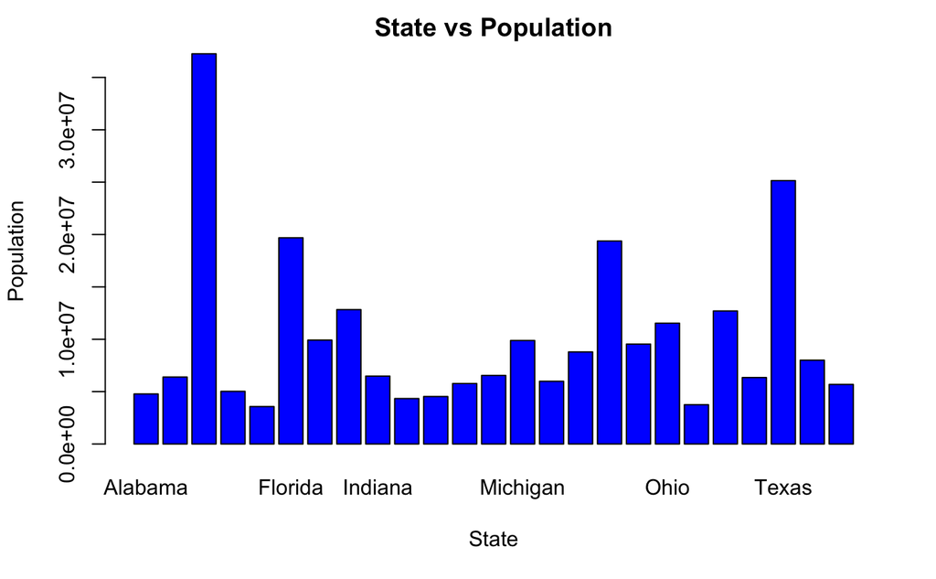

```r
barplot(df$population,
        xlab = 'State',
        ylab = "Population",
        main = "State vs Population",
        names.arg = df$state,
        col = 'blue'
        )
```

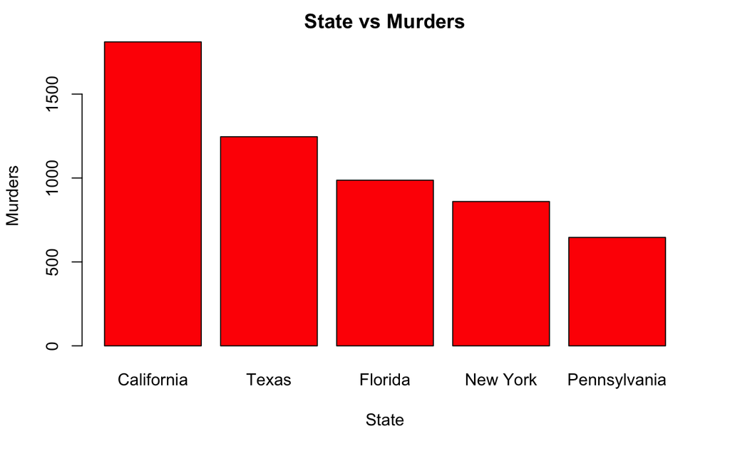

```r
dfprime <- arrange(df, desc(murders)) %>% head(5)
#dfprime

barplot(dfprime$murders,
        xlab = 'State',
        ylab = "Murders",
        main = "State vs Murders",
        names.arg = dfprime$state,
        col = 'red'
        )
```

**Horizontsl Bar Graphs**

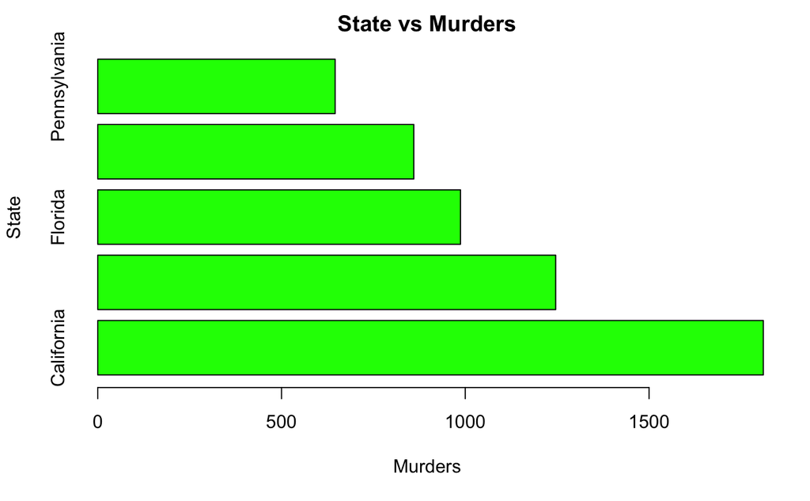

```r
dfprime <- arrange(df, desc(murders)) %>% head(5)
#dfprime

barplot(dfprime$murders,
        xlab = 'Murders',
        ylab = "State",
        main = "State vs Murders",
        names.arg = dfprime$state,
        col = 'green',
        horiz = TRUE
        )
```

**stacked Bar Plots**

```r
library(dplyr)

df <- read.csv('murders.csv')
names(df)
```

```
[1] "X"                 "state"             "abb"               "region"
[5] "population"        "PopulationDensity" "murders"           "gunmurders"
[9] "gunownership"
```

```r
dfprime <- mutate(df, popu = population / 10000)
names(dfprime)
```

```
 [1] "X"                 "state"             "abb"               "region"
 [5] "population"        "PopulationDensity" "murders"           "gunmurders"
 [9] "gunownership"      "popu"
```

```r
dfmatrix <- data.matrix(dfprime[c(2,7,10)])
dfmatrix
```

```
      state murders      popu
 [1,]     1     199  477.9736
 [2,]     2     352  639.2017
 [3,]     3    1811 3725.3956
 [4,]     4     117  502.9196
 [5,]     5     131  357.4097
 [6,]     6     987 1968.7653
 [7,]     7     527  992.0000
 [8,]     8     453 1283.0632
 [9,]     9     198  648.3802
[10,]    10     180  433.9367
[11,]    11     437  453.3372
[12,]    12     424  577.3552
[13,]    13     209  654.7629
[14,]    14     558  988.3640
[15,]    15     419  598.8927
[16,]    16     363  879.1894
[17,]    17     860 1937.8102
[18,]    18     445  953.5483
[19,]    19     460 1153.6504
[20,]    20     188  375.1351
[21,]    21     646 1270.2379
[22,]    22     356  634.6105
[23,]    23    1246 2514.5561
[24,]    24     369  800.1024
[25,]    25     151  568.6986
```

```r
dfmatrix <- t(dfmatrix)
dfmatrix
```

```
            [,1]     [,2]     [,3]     [,4]     [,5]     [,6] [,7]     [,8]     [,9]    [,10]
state     1.0000   2.0000    3.000   4.0000   5.0000    6.000    7    8.000   9.0000  10.0000
murders 199.0000 352.0000 1811.000 117.0000 131.0000  987.000  527  453.000 198.0000 180.0000
popu    477.9736 639.2017 3725.396 502.9196 357.4097 1968.765  992 1283.063 648.3802 433.9367
           [,11]    [,12]    [,13]   [,14]    [,15]    [,16]   [,17]    [,18]   [,19]    [,20]
state    11.0000  12.0000  13.0000  14.000  15.0000  16.0000   17.00  18.0000   19.00  20.0000
murders 437.0000 424.0000 209.0000 558.000 419.0000 363.0000  860.00 445.0000  460.00 188.0000
popu    453.3372 577.3552 654.7629 988.364 598.8927 879.1894 1937.81 953.5483 1153.65 375.1351
           [,21]    [,22]    [,23]    [,24]    [,25]
state     21.000  22.0000   23.000  24.0000  25.0000
murders  646.000 356.0000 1246.000 369.0000 151.0000
popu    1270.238 634.6105 2514.556 800.1024 568.6986
```

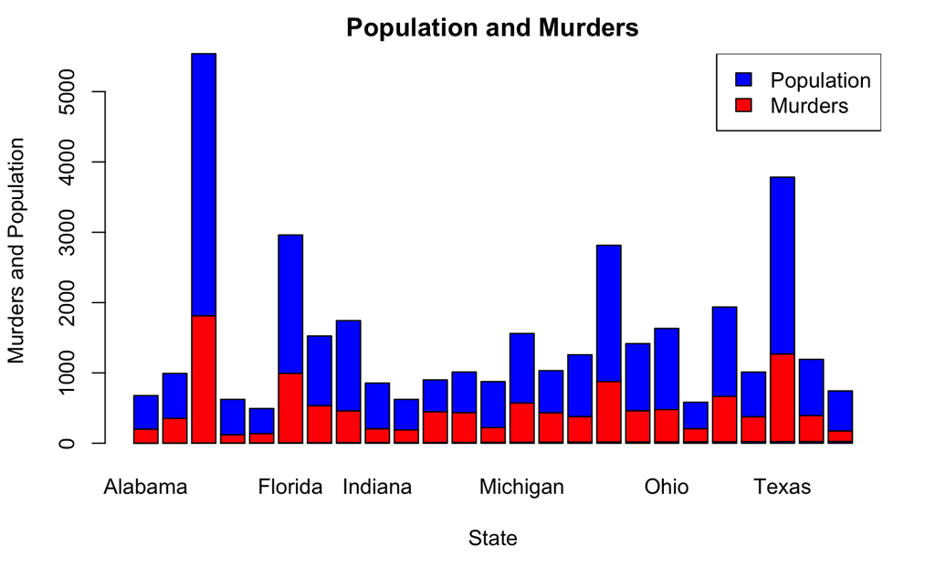

```r
barplot(dfmatrix,
        xlab = 'State',
        ylab = 'Murders and Population',
        main = "Population and Murders",
        names.arg = df$state,
        col = c("blue", 'red')
        )
legend("topright", c("Population", "Murders"), fill = c('blue', 'red'))
```

## 8.2 Histogram

```r
library(dplyr)

df <- read.csv('GEStock.csv')
#df
names(df)
```

```
[1] "X"     "Date"  "Price"
```

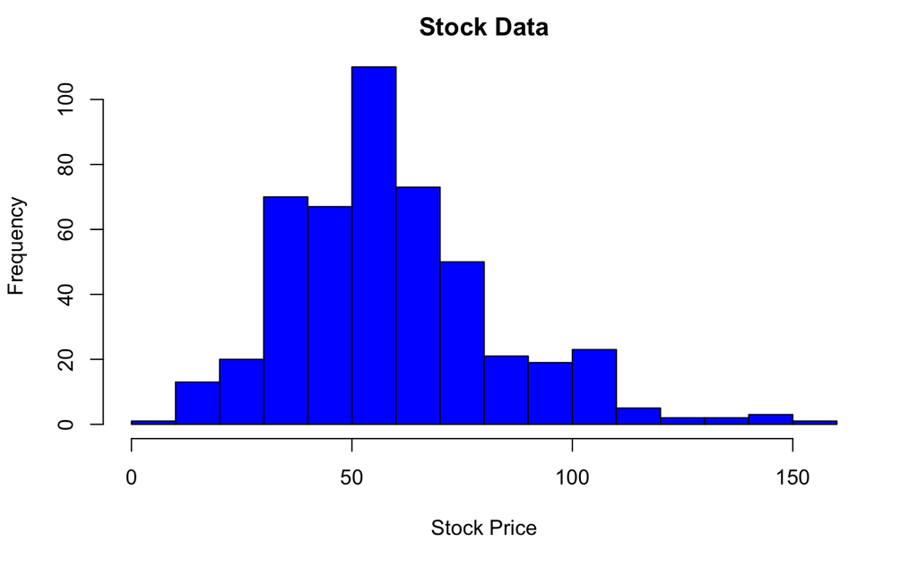

```r
hist(df$Price,
     xlab = 'Stock Price',
     main = "Stock Data",
     col = 'blue',
     border = 'black',
     breaks = 20
     )
```

```r
NA
NA
```

## 8.3 Scatter Plots

The default of `plot` functions is Scatter plot.

```r
library(dplyr)

df <- read.csv('murders.csv')
names(df)
```

```
[1] "X"                 "state"             "abb"               "region"
[5] "population"        "PopulationDensity" "murders"           "gunmurders"
[9] "gunownership"
```

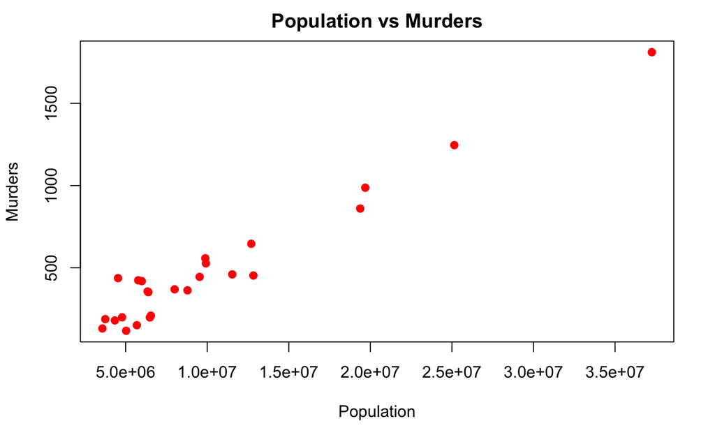

```r
plot(df$population, df$murders,
     xlab = "Population",
     ylab = "Murders",
     main = "Population vs Murders",
     col = 'red',
     pch = 19
     )
```

**pch values**

Values of pch are stored internally as integers.

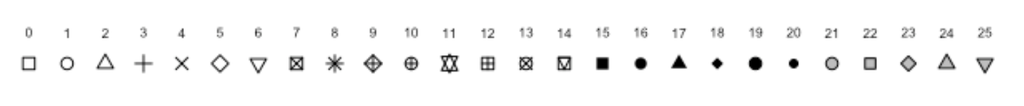

Some values of pch

## 8.4 Line Graphs

```r
library(dplyr)

df <- read.csv('murders.csv')
names(df)
```

```
[1] "X"                 "state"             "abb"               "region"
[5] "population"        "PopulationDensity" "murders"           "gunmurders"
[9] "gunownership"
```

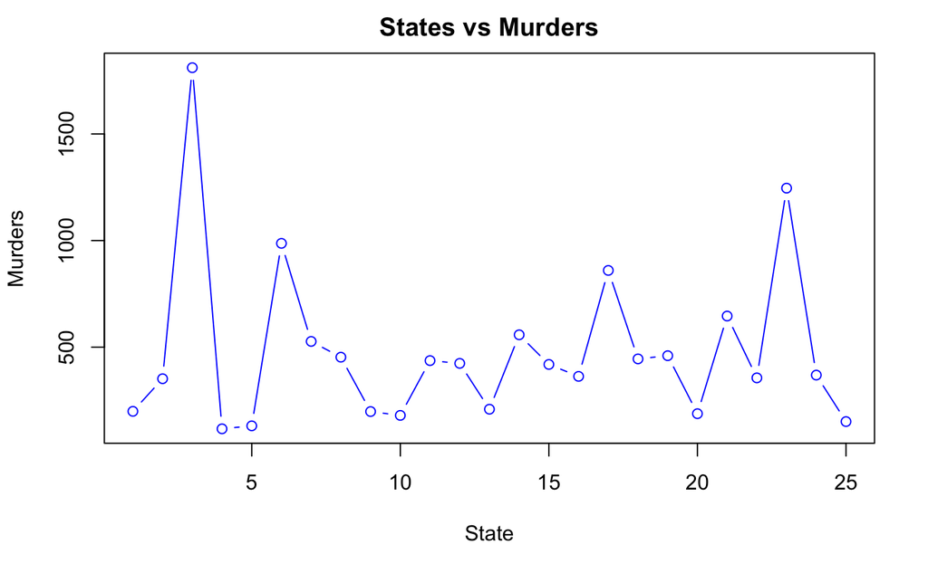

```r
plot(df$murders,
     type = 'b',
     xlab = 'State',
     ylab = "Murders",
     main = "States vs Murders",
     col = 'blue'
     )
```

**`type` in `plot` function**

- **“p”** for points,
- **“l”** for lines,
- **“b”** for both points and lines,
- **“c”** for empty points joined by lines,
- **“o”** for overplotted points and lines,
- **“s”** and **“S”** for stair steps,
- **“h”** for histogram-like vertical lines,
- **“n”** does not produce any points or lines.

## 8.5 Box plots

```r
library(dplyr)
df <- read.csv('murders.csv')
names(df)
```

```
[1] "X"                 "state"             "abb"               "region"
[5] "population"        "PopulationDensity" "murders"           "gunmurders"
[9] "gunownership"
```

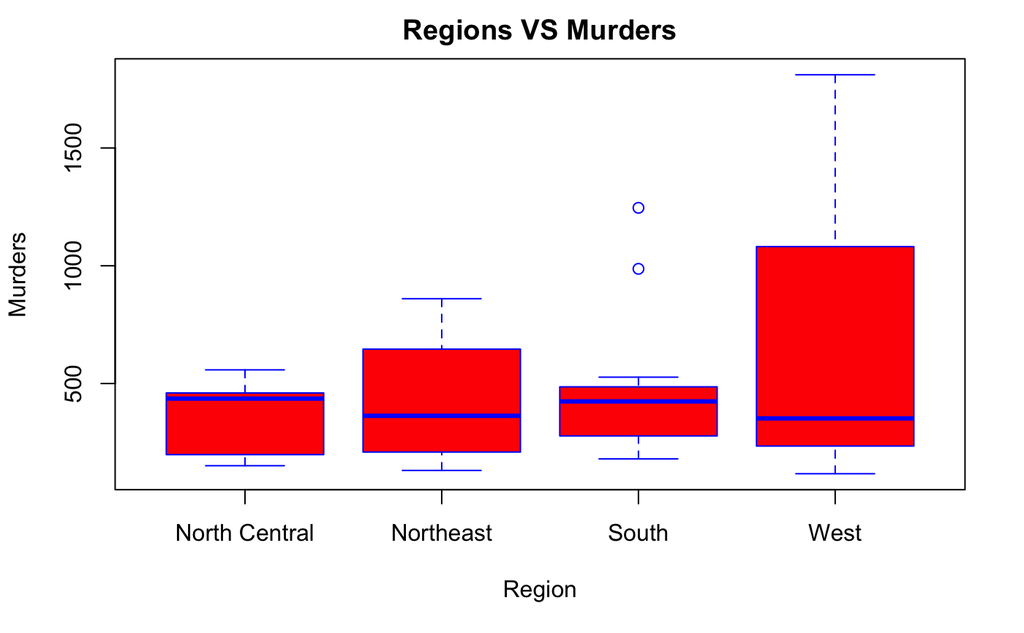

```r
boxplot(df$murders ~ df$region,
        xlab = "Region",
        ylab = "Murders",
        main = "Regions VS Murders",
        col = 'red',
        border = 'blue'
        )
```

## 8.6 Multiple Plots in Layout

```r
par(mfrow = c(1,2))
library(dplyr)
df <- read.csv('murders.csv')
names(df)
```

```
[1] "X"                 "state"             "abb"               "region"
[5] "population"        "PopulationDensity" "murders"           "gunmurders"
[9] "gunownership"
```

```r
dfprime <- mutate(df, popu = population / 10000)
names(dfprime)
```

```
 [1] "X"                 "state"             "abb"               "region"
 [5] "population"        "PopulationDensity" "murders"           "gunmurders"
 [9] "gunownership"      "popu"
```

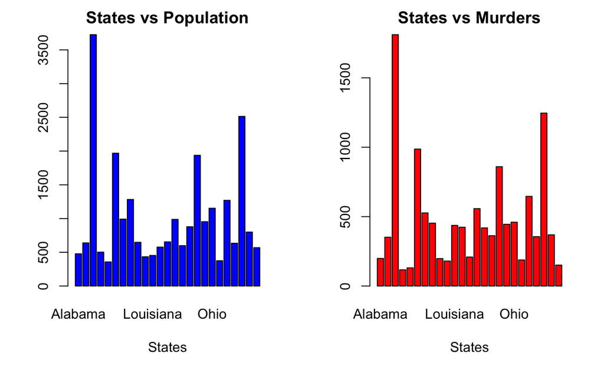

```r
barplot(dfprime$popu,
        xlab = 'States',
        main = "States vs Population",
        col = 'blue',
        names.arg = dfprime$state
        )

barplot(dfprime$murders,
        xlab = 'States',
        main = "States vs Murders",
        col = 'red',
        names.arg = dfprime$state
        )
```

```r
NA
NA
```

```r
par(mfrow = c(2,2))
library(dplyr)
df <- read.csv('murders.csv')
names(df)
```

```
[1] "X"                 "state"             "abb"               "region"
[5] "population"        "PopulationDensity" "murders"           "gunmurders"
[9] "gunownership"
```

```r
dfprime <- mutate(df, popu = population / 10000)
names(dfprime)
```

```
 [1] "X"                 "state"             "abb"               "region"
 [5] "population"        "PopulationDensity" "murders"           "gunmurders"
 [9] "gunownership"      "popu"
```

```r
barplot(dfprime$popu,
        xlab = 'States',
        main = "States vs Population",
        col = 'blue',
        names.arg = dfprime$state
        )

barplot(dfprime$murders,
        xlab = 'States',
        main = "States vs Murders",
        col = 'red',
        names.arg = dfprime$state
        )
```

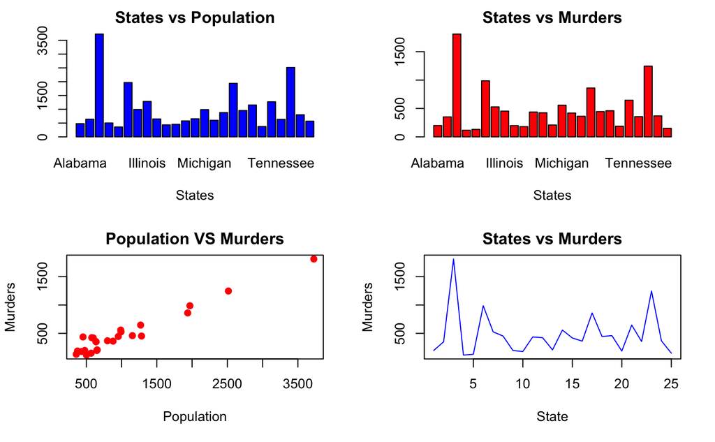

```r
plot(dfprime$popu, df$murders,
     xlab = "Population",
     ylab = "Murders",
     main = 'Population VS Murders',
     col = 'red',
     pch = 19
     )

plot(df$murders,
     type = 'l',
     xlab = 'State',
     ylab = "Murders",
     main = "States vs Murders",
     col = 'blue'
     )
```

[^1]: m.saeed.saffari@ut.ac.ir
[^2]: saeedeh.malekan@ut.ac.ir